# 웹크롤링 강의(PDF편)

# step1

### package 설치

#### package = 함수를 담아놓음 묶음, 설치할 때 install.pakages(“패키지명”), 불러올 때 library(패키지명), 오른쪽 아래 창(Packages)에서 설치 여부 확인

```r
#install.packages("tidyverse")
library(tidyverse)
```

#### tidyverse는 데이터를 불러오고, 정리하고, 변형하는 함수가 내장된 패키지. 시각화, 모델링 함수도 적용.

```r
#install.packages("rvest")
library(rvest)
```

#### 웹에 있는 html 문서를 읽어올 때 사용하는 함수 묶음.

## 분석 데이터1 = “연도별 정부포상 현황”, 행정안전부 자료(흔히 보도자료로 나올 수 있을 만한…)

#### 변수가 무엇인지 탐색 (연도, 계, 훈포장 소계, 훈포장 훈장, 훈포장 포장, 표창 소계, 표창 대표, 표창 국표)

# 1. PDF -> HTML

## 1-1. adobe acrobat DC에서 PDF 파일 열기

## 1-2. PDF HTML 문서로 내보내기

# 2. R에서 html 문서 읽기

## 2-1. read_html(html 문서 읽어오기), html_table(table 속성만 뽑아내기), list -> data.frame [[번호]]

```r
prize_2018 <- read_html('prize_2018.html')

prize_2018 <- html_table(prize_2018, fill = T)
```

#### %>%의 사용

```r
prize_2018 <- read_html('prize_2018.html')

prize_2018 <- prize_2018 %>%
  html_table(fill = T)
```

```r
prize_2018 <- prize_2018[[1]]
```

# 3. 데이터 전처리

## 3-1. str_c(붙이기)

```r
prize_2018[1, ] <- str_c(prize_2018[1, ], "_", prize_2018[2, ])
```

## 3-2. colnames(열 이름)

```r
colnames(prize_2018) <- prize_2018[1, ]
colnames(prize_2018) <- c("연도", "계", "훈포장_소계", "훈포장_훈장", "훈포장_포장", "표창_계", "표창_대표", "표창_국표")
```

## 3-3. slice(행을 추출하거나 잘라내고), select(열을 제외하거나 뽑아내고)

```r
prize_2018 <- prize_2018 %>%
  slice(-1, -2, -3) %>%
  select(-2, -3, -6)
```

## 3-4. glimpse(벡터 속성 확인하기)

```r
glimpse(prize_2018)
```

```
## Observations: 22
## Variables: 5
## $ 연도        <chr> "48∼97", "1998", "1999", "2000", "2001", "2002", "200…
## $ 훈포장_훈장 <chr> "335,553", "12,343", "22,542", "12,631", "6,191", "7,980…
## $ 훈포장_포장 <chr> "80,890", "9,128", "11,812", "6,220", "2,979", "3,039", …
## $ 표창_대표   <chr> "105,368", "7,294", "9,890", "5,882", "4,220", "5,081",…
## $ 표창_국표   <chr> "80,343", "6,728", "9,070", "6,311", "4,960", "5,254", …
```

```r
#prize_2018[1, 4] - prize_2018[1, 5]
```

## 3-5. str_remove(필요없는 문자 지우기, 정규표현식 = 특수문자에는 \), character(문자형 벡터) -> numeric(숫자형 벡터), as.numeric

```r
prize_2018$훈포장_훈장 <- prize_2018$훈포장_훈장 %>%
  str_remove("\\,") %>%
  as.numeric()
```

#### *반복문으로 간편하게

```r
for(i in 2:5){
  prize_2018[,i] <- prize_2018[,i] %>%
    str_remove("\\,") %>%
    as.numeric()
}
```

```r
glimpse(prize_2018)
```

```
## Observations: 22
## Variables: 5
## $ 연도        <chr> "48∼97", "1998", "1999", "2000", "2001", "2002", "200…
## $ 훈포장_훈장 <dbl> 335553, 12343, 22542, 12631, 6191, 7980, 9087, 10658, 13…
## $ 훈포장_포장 <dbl> 80890, 9128, 11812, 6220, 2979, 3039, 3149, 3551, 5052, …
## $ 표창_대표   <dbl> 105368, 7294, 9890, 5882, 4220, 5081, 4779, 4803, 5701,…
## $ 표창_국표   <dbl> 80343, 6728, 9070, 6311, 4960, 5254, 5021, 5336, 6759, …
```

# 4. 데이터 분석하기

## 4-1. mutate

#### *데이터프레임에 조건을 만족하는 새로운 열(변수)를 만들거나, 기존의 열을 조건에 맞게 변경할 때 사용

```r
prize_2018 <- prize_2018 %>%
  mutate(훈포장_계 = 훈포장_훈장 + 훈포장_포장,
         표창_계 = 표창_대표 + 표창_국표)
```

## 4-2. gather(모으고), spread(펼치고), separate(분리하고)

#### *왜 모으는 지는 그래프 그려보면 알 수 있음

```r
prize_2018 <- prize_2018 %>%
  gather(cate, num, 2:7)
# prize_2018 <- prize_2018 %>%
#  spread(cate, num)
# *mutate, summarise 연산할 때 편함
```

```r
prize_2018 <- prize_2018 %>%
  separate(cate, c("cate1", "cate2"), sep = "\\_")
```

## 4-3. 시각화

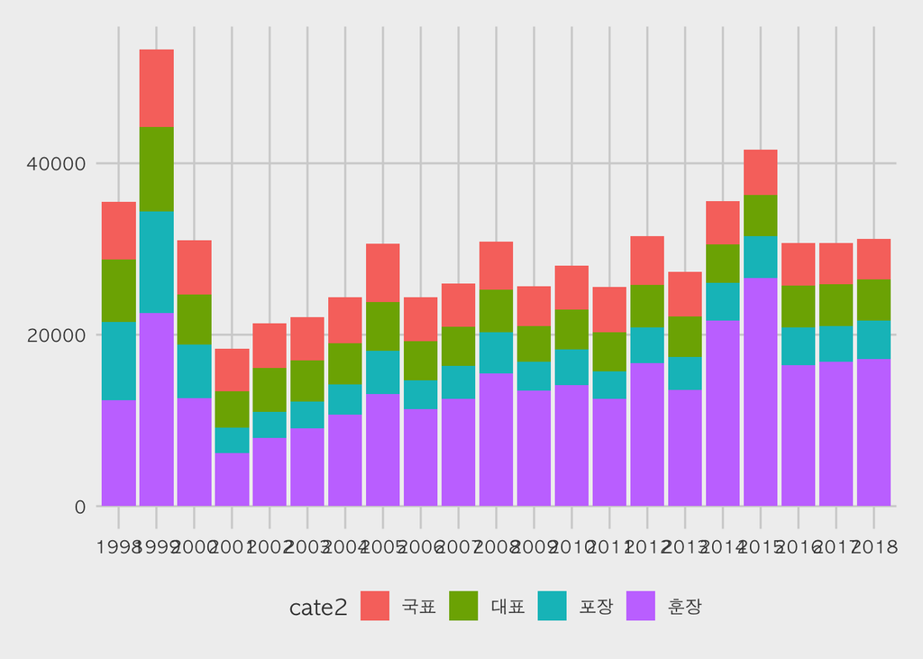

```r
library(ggthemes)

ggplot(prize_2018 %>%
         filter(연도 != "48∼97", cate2 != "계"), aes(x = 연도, y = num, fill = cate2)) +
  geom_col() +
  theme_fivethirtyeight(base_family = "AppleGothic")
```

## 4-4. 의미 분석

#### 1. 변수를 바꿔 넣어가면서 의미를 분석, filter(특정 요건에 맞춰 데이터 추출하는 함수)

#### 2. 정권 별로 그룹화해서 특정 정권에 포상을 남발한 원인 분석 -> 월 단위 데이터 요청

#### 3. 특정연도에 늘어난 이유(예 : 99년 “공무원의 명예퇴직이나 교원들의 정년 인하로 퇴직자가 늘어 갑작스럽게 국민훈장과 근정훈장에 대한 수요가 증가했기 때문”) -> 훈장의 세부종류별 데이터 요청

# 5. 실제 데이터로 실습하기

#### 국토부 보도자료(http://www.molit.go.kr/USR/NEWS/m_71/dtl.jsp?lcmspage=1&id=95082344)

#### 1. read_html()와 html_table() 함수를 이용해 training.html의 데이터를 가져와 {df_country}에 담아보세요.

#### 2. {df_country}의 7번째 데이터프레임을 {df_country}에 담아보세요.

#### 3. {df_country}의 열 이름을 {df_country}의 첫행으로 바꿔보세요.

#### 3-1. 1~3번째 ’행’을 slice() 함수를 이용해 지워보세요.

#### 4. {df_country}의 자료구조를 파악해 보세요.

#### 5. gather() 함수를 이용해 {df_country}의 숫자형태(아직은 문자형인) 데이터(2열부터 9열까지)를 모아보세요. 변수는 cate, num입니다.

#### 6. {df_country}의 변수 num(df_country$num)에서 str_remove_all() 함수를 이용해 ’,’를 지운 뒤 문자형을 숫자형으로 변환하는 함수 as.numeric()을 써서 숫자형 데이터로 변환해 보세요.

#### 7. spread() 함수를 이용해 {df_country}의 숫자형 데이터를 펼쳐보세요.

#### 8. mutate() 함수를 이용해 17개 지자체 토지 가운데,

#### 8-1. 하천이 차지하는 비율을 계산해 변수 ’하천_비율’에 담아보세요.

#### 8-2. 전, 답, 대 면적의 합을 계산해 변수 ’농지’에 담아보세요.